# Project1_siyitao

Siyi Tao

9/17/2017

Republican Party and Democratic Party have been the hottest two political parties in the history of America, since the president of America usually comes from these two parties. To understand more about Republican Party and Democratic Party, we would like to do some research on each president’s inauguration speeches. This project is supposed to answer one significant question: What are the differences and similarities between Republican Party and Democratic Party?

Before we begin, we should check and install needed packages, as well as load the libraries.

# Step 0: check and install needed packages. Load the libraries and functions.

```r
packages.used=c("wordcloud", "xlsx", "tm", "tidytext", "RColorBrewer",
                "syuzhet", "qdap", "readr", "dplyr", "rpart", "e1071",
                "ggplot2", "reshape2", "class")
# check packages that need to be installed.
packages.needed=setdiff(packages.used,
                        intersect(installed.packages()[,1],
                                  packages.used))
# install additional packages
if(length(packages.needed)>0){
  install.packages(packages.needed, dependencies = TRUE,
                   repos='http://cran.us.r-project.org')
}
library(wordcloud)
library(xlsx)
library(tm)
library(tidytext)
library(RColorBrewer)
library(syuzhet)
library(qdap)
library(readr)
library(dplyr)
library(rpart)
library(class)
library(e1071)
library(ggplot2)
library(reshape2)
```

For the first step, we read all needed data: InaugurationInfo.xlsx, and inaugural speeches text files into R. After loading, we do necessary transformations to data so they can be used in the next step.

# Step 1: Text processing

```r
#Read all speech documents into a corpus
folder.path="../data/inauguralSpeeches"
speeches=list.files(path = folder.path, pattern = "*.txt")
ff.all<-Corpus(DirSource(folder.path))
#Read inaugural speech information
inaug_info <- read.xlsx(file="../data/InaugurationInfo.xlsx",
 sheetName = "Sheet1", as.data.frame=TRUE, header=TRUE, stringsAsFactors = FALSE)

#Separate into two parties
file_repub <- paste("inaug", inaug_info$File[inaug_info$Party=="Republican"],
          "-", inaug_info$Term[inaug_info$Party=="Republican"], ".txt", sep="")
file_democ <- paste("inaug", inaug_info$File[inaug_info$Party=="Democratic"],
          "-", inaug_info$Term[inaug_info$Party=="Democratic"], ".txt", sep="")

#Remove words that may cause misunderstandings
ff.all<-tm_map(ff.all, stripWhitespace)
ff.all<-tm_map(ff.all, content_transformer(tolower))
ff.all<-tm_map(ff.all, removeWords, stopwords("english"))
ff.all<-tm_map(ff.all, removeWords, character(0))
ff.all<-tm_map(ff.all, removePunctuation)

dtm <- DocumentTermMatrix(ff.all,
                          control = list(weighting = function(x)
                                             weightTfIdf(x,
                                                         normalize =FALSE),
                                         stopwords = TRUE))

dtm.matrix <- t(as.matrix(dtm))
dtm.matrix.repub <- rowSums(dtm.matrix[,colnames(dtm.matrix) %in% file_repub])
dtm.matrix.democ <- rowSums(dtm.matrix[,colnames(dtm.matrix) %in% file_democ])
dtm.matrix.new <- cbind(dtm.matrix.repub, dtm.matrix.democ)
colnames(dtm.matrix.new) <- c("Republican", "Democratic")

ff.dtm=tidy(dtm)
#Read term, frequency for separate parties
term_repub <- ff.dtm$term[ff.dtm$document %in% file_repub]
count_repub <- ff.dtm$count[ff.dtm$document %in% file_repub]
term_democ <- ff.dtm$term[ff.dtm$document %in% file_democ]
count_democ <- ff.dtm$count[ff.dtm$document %in% file_democ]
```

# Step 2: Visualization - Word Cloud

The first plot is a word cloud of republican party. As we can see from the picture, republican party focuses on nergo, tariff, business and loans, which are the most realistic issues in America.

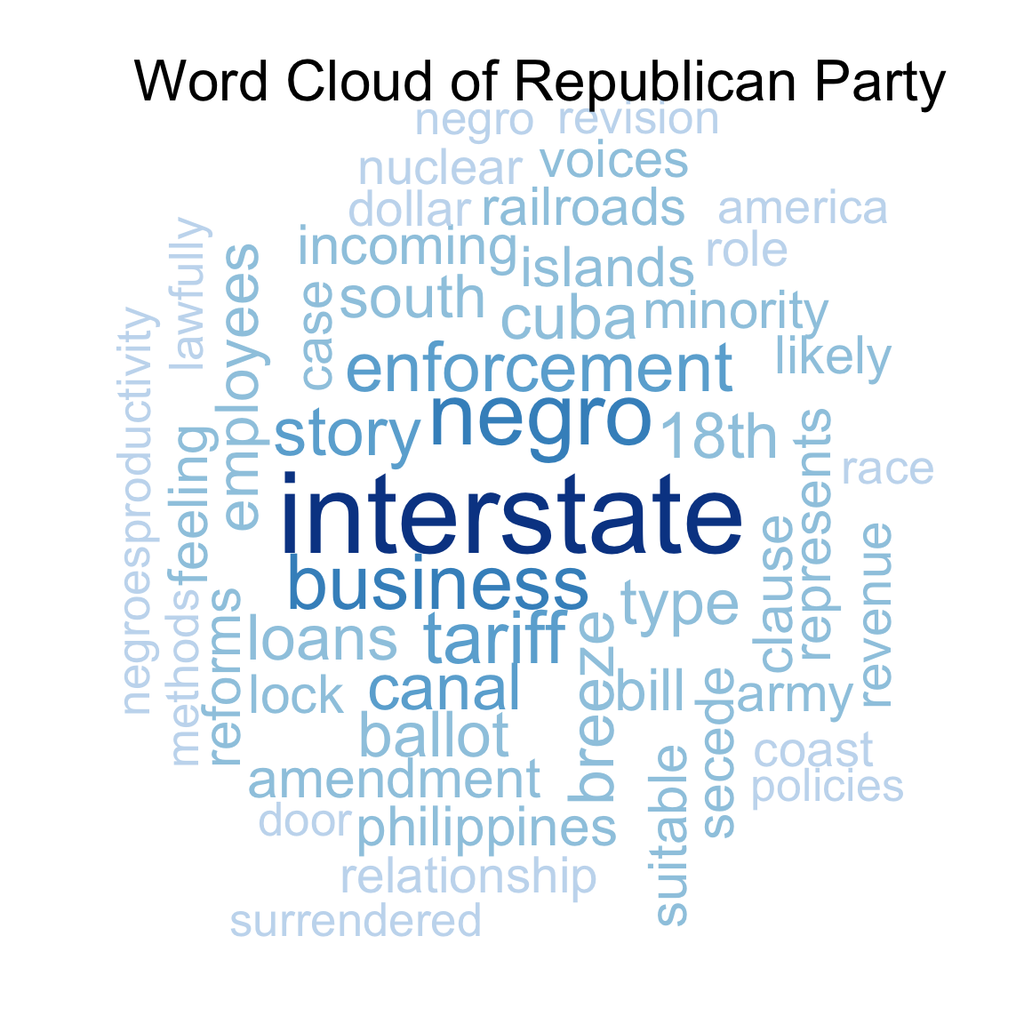

```r
wordcloud(term_repub, count_repub,
              scale=c(4,0.5),
              max.words=50,
              min.freq=3,
              random.order=FALSE,
              rot.per=0.4,
              use.r.layout=FALSE,
              random.color=FALSE,
              colors=brewer.pal(8,"Blues"))
text(x= 0.53, y=0.95, "Word Cloud of Republican Party", cex=2)
```

```r
dev.copy(jpeg,filename='../output/wordcloud-republican.jpg');
```

```r
dev.off();
```

The second plot is a word cloud of democratic party. We can notice that Texas has been the most frequent word that democratic party uses, but Texas is known as one of the most Republican states in the U.S. Republicans control all statewide Texas offices, both houses of the state legislature and have a majority in the Texas congressional delegation. Democratic party seems to put a great emphasis on strengthening connections among different states in America.

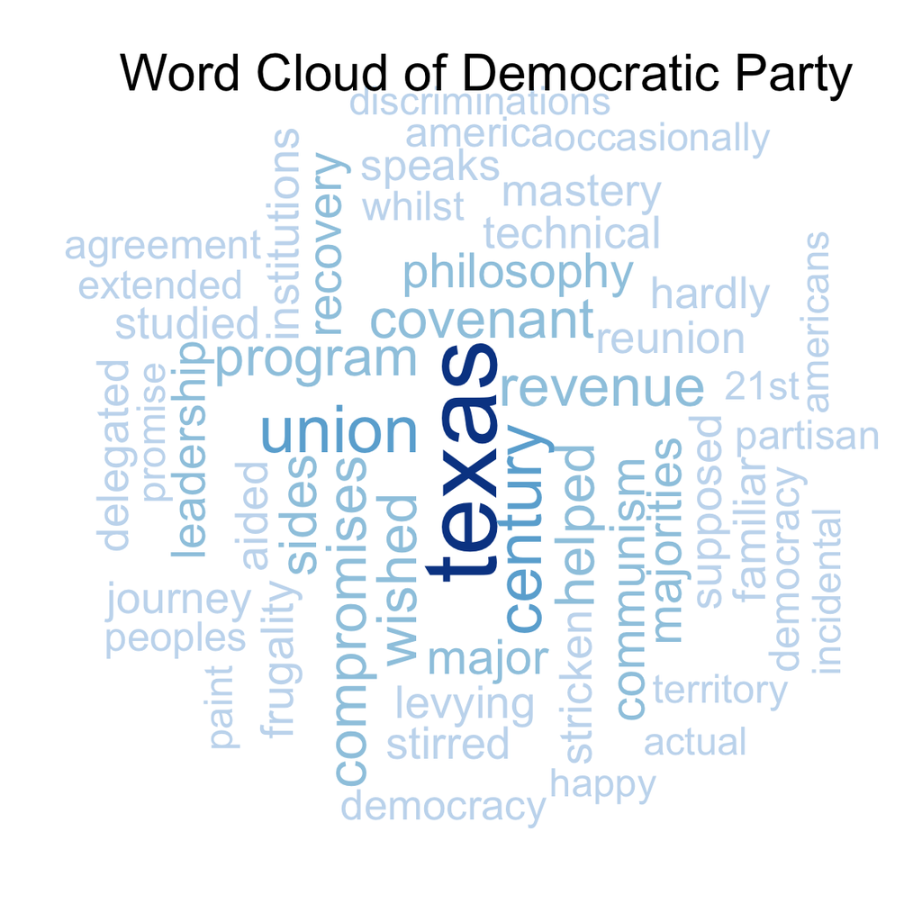

```r
wordcloud(term_democ, count_democ,
              scale=c(4,0.5),
              max.words=50,
              min.freq=3,
              random.order=FALSE,
              rot.per=0.4,
              use.r.layout=FALSE,
              random.color=FALSE,
              colors=brewer.pal(8,"Blues"))
text(x= 0.53, y=0.95, "Word Cloud of Democratic Party", cex=2)
```

```r
dev.copy(jpeg,filename='../output/wordcloud-democratic.jpg');
```

```r
dev.off();
```

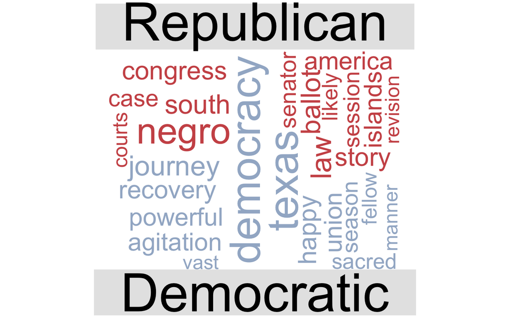

```r
comparison.cloud(dtm.matrix.new,
                 scale=c(4,0.5),
                 max.words=100,
                 random.order=FALSE,
                 rot.per=.3,
                 colors=c("indianred3","lightsteelblue3"),
                 use.r.layout=FALSE,
                 title.size=5)
```

```r
dev.copy(jpeg,filename='../output/wordcloud-comparison.jpg');
```

```r
dev.off();
```

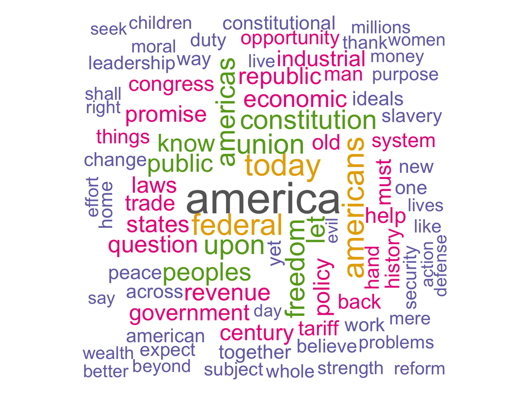

```r
commonality.cloud(dtm.matrix.new,
                  random.order=FALSE,
                  scale=c(4, 0.5),
                  colors = brewer.pal(8, "Dark2"),
                  max.words=100)
```

```r
dev.copy(jpeg,filename='../output/wordcloud-commonality.jpg');
```

```r
dev.off();
```

# Step 3: Data Processing - Sentiment Analysis

This step is used to transform data for use in the following two steps.

```r
#Remove inaugural speeches information of presidents from other parties
inaug_info.new <- inaug_info[which(inaug_info$Party=="Republican" |
                     inaug_info$Party=="Democratic"),]

file_term_to_text <- function(file, term){
  text <- read_file(paste("../data/inauguralSpeeches/inaug", file,
                         "-", term, ".txt", sep=""))
  return(text)}
#Read all speech text files into inaug_info.new data frame
inaug_info.new$fulltext <-  mapply(file_term_to_text, inaug_info.new$File,
                                   inaug_info.new$Term)

#Do sentiment analysis and read all results into sentence.df data frame
sentence.df <- NULL

for (i in 1:nrow(inaug_info.new)){
  sentences=sent_detect(inaug_info.new$fulltext[i],
                        endmarks = c("?", ".", "!", "|",";"))
  if (length(sentences)>0){
    for (j in 1:length(sentences)){

        emotions <- get_nrc_sentiment(sentences[j])

        word.count <- word_count(sentences[j])
        emotions <- 1/(word.count+0.01)*unlist(emotions)
        new_record <- unlist(c(inaug_info.new[i,-ncol(inaug_info.new)],
                            word.count, emotions, sentences[j]))
        new_record <- unname(new_record)
        sentence.df <- rbind(sentence.df, new_record)
    }
  }
}


sentence.df.new <- as.data.frame(sentence.df, row.names = NULL,
                                 stringsAsFactors = FALSE)
colnames(sentence.df.new) <- c("President","File", "Term", "Party", "Words",
                            "Word_Count", "anger", "anticipation","disgust",
                            "fear", "joy", "sadness", "surprise", "trust",
                            "negative", "positive", "Sentences")
row.names(sentence.df.new) <- NULL
#Change all score to numeric type
sentence.df.new$anger <- as.numeric(sentence.df.new$anger)
sentence.df.new$anticipation <- as.numeric(sentence.df.new$anticipation)
sentence.df.new$disgust <- as.numeric(sentence.df.new$disgust)
sentence.df.new$fear <- as.numeric(sentence.df.new$fear)
sentence.df.new$joy <- as.numeric(sentence.df.new$joy)
sentence.df.new$sadness <- as.numeric(sentence.df.new$sadness)
sentence.df.new$surprise <- as.numeric(sentence.df.new$surprise)
sentence.df.new$trust <- as.numeric(sentence.df.new$trust)
sentence.df.new$positive <- as.numeric(sentence.df.new$positive)
sentence.df.new$negative <- as.numeric(sentence.df.new$negative)

final.df <- sentence.df.new[,c("President", "Party", "anger","anticipation",
                                "disgust","fear", "joy", "sadness",
                                "surprise", "trust", "negative", "positive")]
final.df_center <- colMeans(final.df[,-c(1,2,11,12)],
                                  na.rm=TRUE)
final_tbl <- tbl_df(final.df)%>%group_by(President) %>% summarise(
    Party = Party[1],
    anger=mean(anger, na.rm=TRUE),
    anticipation=mean(anticipation, na.rm=TRUE),
    disgust=mean(disgust, na.rm=TRUE),
    fear=mean(fear, na.rm=TRUE),
    joy=mean(joy, na.rm=TRUE),
    sadness=mean(sadness, na.rm=TRUE),
    surprise=mean(surprise, na.rm=TRUE),
    trust=mean(trust, na.rm=TRUE))
final_mat <- as.matrix(final_tbl[,-c(1,2)])
```

# Step 4: Unsupervised Learning - K Means/Hierarchical Agglomerative

I tried to use two common unsupervised learning methods: K Means, and Hierarchical Agglomerative to cluster sentiment analysis results. My ideal result is that they can be separated into two clusters, one is for Democratic Party and another is for Republican Party. But the fact is that the accuracy is usually around 50%, which means there is no obvious difference between emotions from Democratic Party and that from Republican Party.

```r
# K Means
km.res <- kmeans(x = final_mat, centers=2, iter.max=2000,
                 algorithm="MacQueen")
kmeans_cluster <- km.res$cluster
party <- unname(final_tbl$Party)
party_cluster.1 <- replace(party, party=="Republican", 1)
party_cluster.1 <- as.numeric(replace(party_cluster.1,
                                      party_cluster.1=="Democratic", 2))
party_cluster.2 <- replace(party, party=="Republican", 2)
party_cluster.2 <- as.numeric(replace(party_cluster.2,
                                      party_cluster.2=="Democratic", 1))
mean(party_cluster.1==kmeans_cluster)
```

```
## [1] 0.59375
```

```r
mean(party_cluster.2==kmeans_cluster)
```

```
## [1] 0.40625
```

```r
# Hierarchical Agglomerative
d <- dist(final_mat, method = "euclidean") # distance matrix
fit <- hclust(d, method="ward.D")
groups <- cutree(fit, k=2)
mean(party_cluster.1==groups)
```

```
## [1] 0.5
```

```r
mean(party_cluster.2==groups)
```

```
## [1] 0.5
```